```python
import warnings
warnings.filterwarnings('ignore')
```

# Predicting Online Shoppers Behaviors

# Origins of Dataset

Dataset was derived from https://archive.ics.uci.edu/ml/datasets/Online+Shoppers+Purchasing+Intention+Dataset.

I wanted to learn more about the dataset and found the academic paper written about the data entitled, “Real-time prediction of online shoppers’ purchasing intention using multilayer perceptron and LSTM recurrent neural networks” by C. Okan Sakar, S. Olcay Polat, Mete Katircioglu, and Yomi Kastro.

# Dataset Description

The dataset consists of 12,330 customer sessions (rows), 10 numerical and 8 categorical variables (columns). I will use ‘Revenue’ (True or False) variable as my target variable. The other 17 variables will be my predictor variables, customer's attributes, or features. I will engineer more attributes before modeling. This dataset was formed in a one-year period not including holidays, special days, or specific campaigns. The size of the data set is adequate for the data science tasks I plan on performing on it.

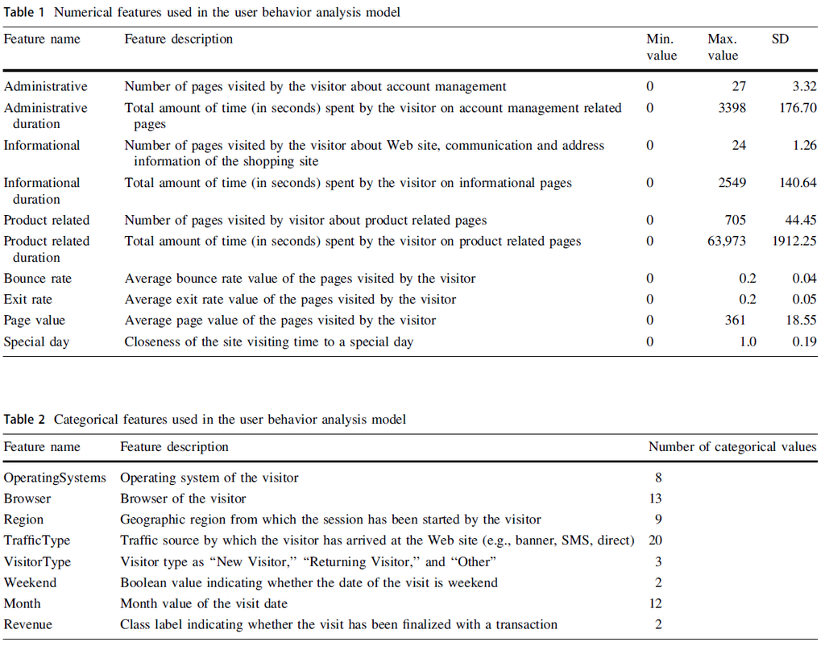

# Loading Libraries

```python
# Load Python libraries for visualizing data.
import numpy as np
import pandas as pd
import matplotlib.pyplot as plt
import seaborn as sns
```

# Loading Dataset

```python
df = pd.read_csv('data.csv')
df.head()
```

|  | Administrative | Administrative_Duration | Informational | Informational_Duration | ProductRelated | ProductRelated_Duration | BounceRates | ExitRates | PageValues | SpecialDay | Month | OperatingSystems | Browser | Region | TrafficType | VisitorType | Weekend | Revenue |
| --- | --- | --- | --- | --- | --- | --- | --- | --- | --- | --- | --- | --- | --- | --- | --- | --- | --- | --- |
| 0 | 0 | 0.0 | 0 | 0.0 | 1 | 0.000000 | 0.20 | 0.20 | 0.0 | 0.0 | Feb | 1 | 1 | 1 | 1 | Returning_Visitor | False | False |
| 1 | 0 | 0.0 | 0 | 0.0 | 2 | 64.000000 | 0.00 | 0.10 | 0.0 | 0.0 | Feb | 2 | 2 | 1 | 2 | Returning_Visitor | False | False |
| 2 | 0 | 0.0 | 0 | 0.0 | 1 | 0.000000 | 0.20 | 0.20 | 0.0 | 0.0 | Feb | 4 | 1 | 9 | 3 | Returning_Visitor | False | False |
| 3 | 0 | 0.0 | 0 | 0.0 | 2 | 2.666667 | 0.05 | 0.14 | 0.0 | 0.0 | Feb | 3 | 2 | 2 | 4 | Returning_Visitor | False | False |
| 4 | 0 | 0.0 | 0 | 0.0 | 10 | 627.500000 | 0.02 | 0.05 | 0.0 | 0.0 | Feb | 3 | 3 | 1 | 4 | Returning_Visitor | True | False |

# Data Inspection

```python
# Display the shape of the dataset.
df.shape
```

```
(12330, 18)
```

```python
df.info()
```

```
<class 'pandas.core.frame.DataFrame'>
RangeIndex: 12330 entries, 0 to 12329
Data columns (total 18 columns):
 #   Column                   Non-Null Count  Dtype
---  ------                   --------------  -----
 0   Administrative           12330 non-null  int64
 1   Administrative_Duration  12330 non-null  float64
 2   Informational            12330 non-null  int64
 3   Informational_Duration   12330 non-null  float64
 4   ProductRelated           12330 non-null  int64
 5   ProductRelated_Duration  12330 non-null  float64
 6   BounceRates              12330 non-null  float64
 7   ExitRates                12330 non-null  float64
 8   PageValues               12330 non-null  float64
 9   SpecialDay               12330 non-null  float64
 10  Month                    12330 non-null  object
 11  OperatingSystems         12330 non-null  int64
 12  Browser                  12330 non-null  int64
 13  Region                   12330 non-null  int64
 14  TrafficType              12330 non-null  int64
 15  VisitorType              12330 non-null  object
 16  Weekend                  12330 non-null  bool
 17  Revenue                  12330 non-null  bool
dtypes: bool(2), float64(7), int64(7), object(2)
memory usage: 1.5+ MB
```

```python
# Display na or nan values.
df.isnull().sum()
```

```
Administrative             0
Administrative_Duration    0
Informational              0
Informational_Duration     0
ProductRelated             0
ProductRelated_Duration    0
BounceRates                0
ExitRates                  0
PageValues                 0
SpecialDay                 0
Month                      0
OperatingSystems           0
Browser                    0
Region                     0
TrafficType                0
VisitorType                0
Weekend                    0
Revenue                    0
dtype: int64
```

```python
# Display descriptive statistics.
df.describe(include='all').transpose()
```

|  | count | unique | top | freq | mean | std | min | 25% | 50% | 75% | max |
| --- | --- | --- | --- | --- | --- | --- | --- | --- | --- | --- | --- |
| Administrative | 12330.0 | NaN | NaN | NaN | 2.315166 | 3.321784 | 0.0 | 0.0 | 1.0 | 4.0 | 27.0 |
| Administrative_Duration | 12330.0 | NaN | NaN | NaN | 80.818611 | 176.779107 | 0.0 | 0.0 | 7.5 | 93.25625 | 3398.75 |
| Informational | 12330.0 | NaN | NaN | NaN | 0.503569 | 1.270156 | 0.0 | 0.0 | 0.0 | 0.0 | 24.0 |
| Informational_Duration | 12330.0 | NaN | NaN | NaN | 34.472398 | 140.749294 | 0.0 | 0.0 | 0.0 | 0.0 | 2549.375 |
| ProductRelated | 12330.0 | NaN | NaN | NaN | 31.731468 | 44.475503 | 0.0 | 7.0 | 18.0 | 38.0 | 705.0 |
| ProductRelated_Duration | 12330.0 | NaN | NaN | NaN | 1194.74622 | 1913.669288 | 0.0 | 184.1375 | 598.936905 | 1464.157214 | 63973.52223 |
| BounceRates | 12330.0 | NaN | NaN | NaN | 0.022191 | 0.048488 | 0.0 | 0.0 | 0.003112 | 0.016813 | 0.2 |
| ExitRates | 12330.0 | NaN | NaN | NaN | 0.043073 | 0.048597 | 0.0 | 0.014286 | 0.025156 | 0.05 | 0.2 |
| PageValues | 12330.0 | NaN | NaN | NaN | 5.889258 | 18.568437 | 0.0 | 0.0 | 0.0 | 0.0 | 361.763742 |
| SpecialDay | 12330.0 | NaN | NaN | NaN | 0.061427 | 0.198917 | 0.0 | 0.0 | 0.0 | 0.0 | 1.0 |
| Month | 12330 | 10 | May | 3364 | NaN | NaN | NaN | NaN | NaN | NaN | NaN |
| OperatingSystems | 12330.0 | NaN | NaN | NaN | 2.124006 | 0.911325 | 1.0 | 2.0 | 2.0 | 3.0 | 8.0 |
| Browser | 12330.0 | NaN | NaN | NaN | 2.357097 | 1.717277 | 1.0 | 2.0 | 2.0 | 2.0 | 13.0 |
| Region | 12330.0 | NaN | NaN | NaN | 3.147364 | 2.401591 | 1.0 | 1.0 | 3.0 | 4.0 | 9.0 |
| TrafficType | 12330.0 | NaN | NaN | NaN | 4.069586 | 4.025169 | 1.0 | 2.0 | 2.0 | 4.0 | 20.0 |
| VisitorType | 12330 | 3 | Returning_Visitor | 10551 | NaN | NaN | NaN | NaN | NaN | NaN | NaN |
| Weekend | 12330 | 2 | False | 9462 | NaN | NaN | NaN | NaN | NaN | NaN | NaN |
| Revenue | 12330 | 2 | False | 10422 | NaN | NaN | NaN | NaN | NaN | NaN | NaN |

```python
# Manipulate the column datatypes.
df['OperatingSystems'] = df['OperatingSystems'].astype('str')
df['Browser'] = df['Browser'].astype('str')
df['Region'] = df['Region'].astype('str')
df['TrafficType'] = df['TrafficType'].astype('str')

# Convert dtype from boolean to string.
df['Weekend'] = df['Weekend'].astype('str')
df['Revenue'] = df['Revenue'].astype('str')
```

```python
# Verifying the data types changed.
df.dtypes
```

```
Administrative               int64
Administrative_Duration    float64
Informational                int64
Informational_Duration     float64
ProductRelated               int64
ProductRelated_Duration    float64
BounceRates                float64
ExitRates                  float64
PageValues                 float64
SpecialDay                 float64
Month                       object
OperatingSystems            object
Browser                     object
Region                      object
TrafficType                 object
VisitorType                 object
Weekend                     object
Revenue                     object
dtype: object
```

# Target Variable Analysis

```python
# Display value count of target variable.
df['Revenue'].value_counts()
```

```
Revenue
False    10422
True      1908
Name: count, dtype: int64
```

```python
# Percent breakdown of the Revenue rates.
rate = df['Revenue'].value_counts()/df.shape[0]
print(rate)
```

```
Revenue
False    0.845255
True     0.154745
Name: count, dtype: float64
```

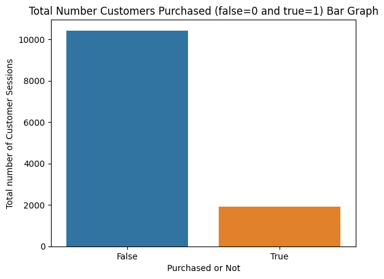

```python
# Create bar graph of the Revenue.
sns.countplot(x='Revenue', data=df)
plt.xlabel('Purchased or Not')
plt.ylabel('Total number of Customer Sessions')
plt.title('Total Number Customers Purchased (false=0 and true=1) Bar Graph')
plt.show()
```

There is a clear imbalance in the classes of the target variable. While evaluating the machine learning models, I will chooose the appropriate metrics to select the appropriate classification model.

# EDA

```python
# Create dataframe for categorical variables.
cat_df = [f for f in df.columns if df.dtypes[f] == 'object']
cat_df = df[cat_df]
```

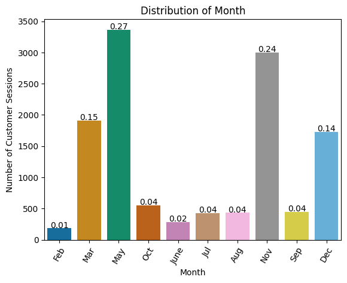

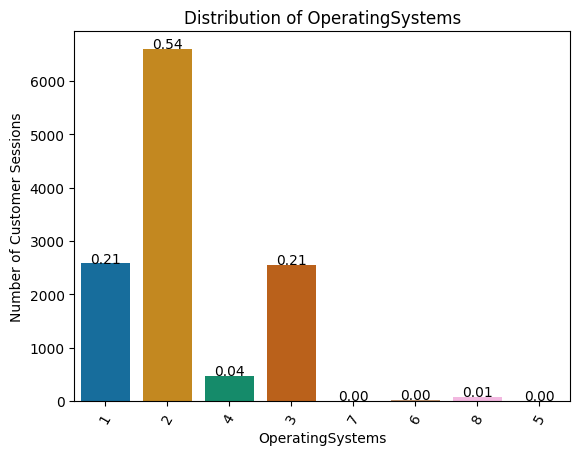

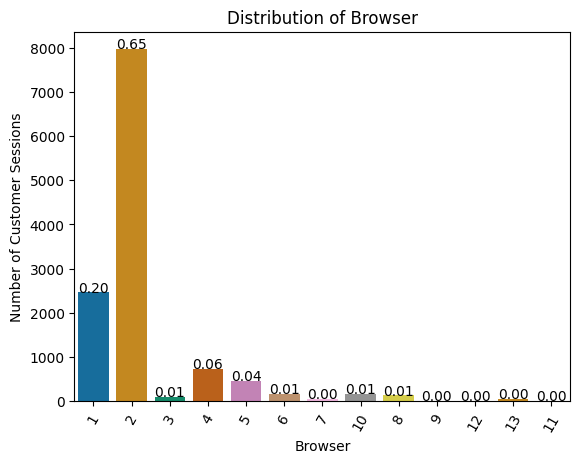

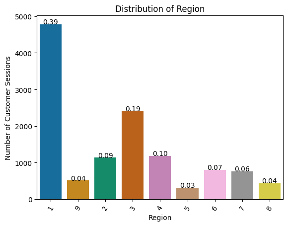

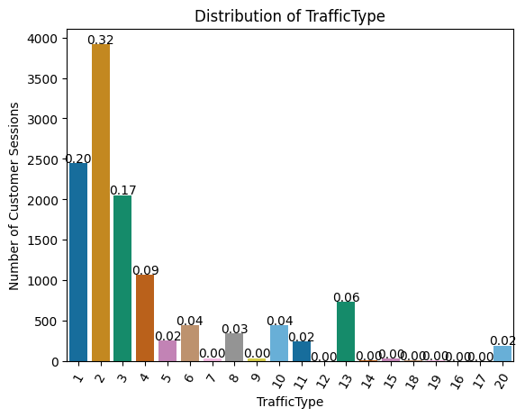

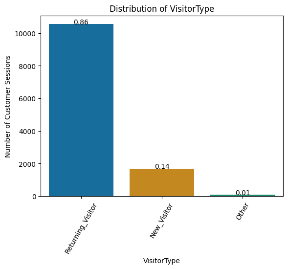

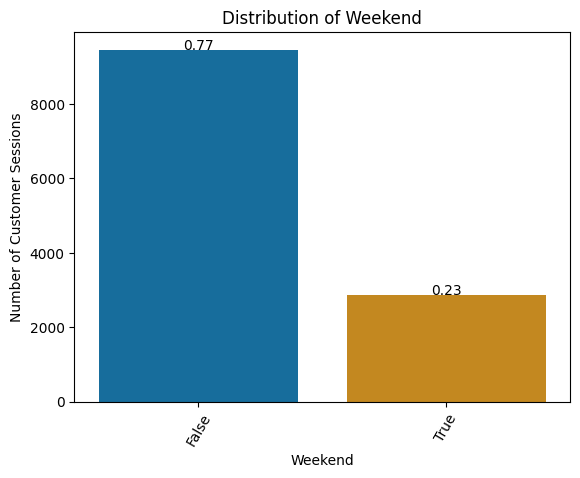

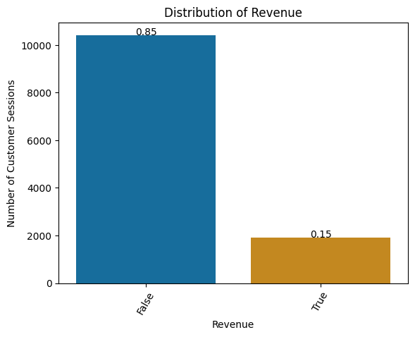

```python
# Plot distributions of categorical variables.
for var in cat_df.columns:
    ax = sns.countplot(x = df[var], data = df, palette = 'colorblind')
    total = float(len(df[var]))
    for p in ax.patches:
        height = p.get_height()
        ax.text(p.get_x() + p.get_width() / 2.,
                height + 10,
                '{:1.2f}'.format(height/total),
                ha="center")
    plt.title('Distribution of ' + str(var))
    plt.ylabel('Number of Customer Sessions')
    plt.xticks(rotation = 60)
    plt.show()
```

Most customers shop in the months of May and November and do most of their shopping during the week. They use operating system 2, browser 2, and use traffic type 2. They live in region 1 and are returning customers. Most of the do not purchase anything and are on the website to shop.

```python
# Split the numeric variables.
num_df = [f for f in df.columns if df.dtypes[f] != 'object']

# Create dataframe for numeric variables.
num_df = df[num_df]
```

```python
num_df.columns
```

```
Index(['Administrative', 'Administrative_Duration', 'Informational',
       'Informational_Duration', 'ProductRelated', 'ProductRelated_Duration',
       'BounceRates', 'ExitRates', 'PageValues', 'SpecialDay'],
      dtype='object')
```

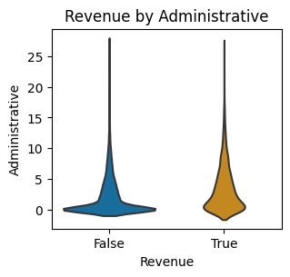

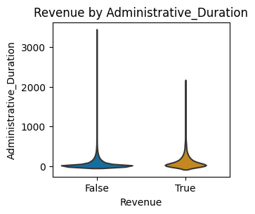

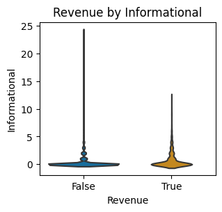

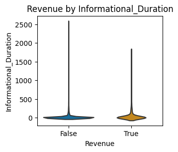

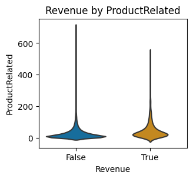

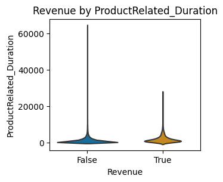

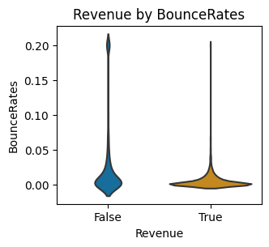

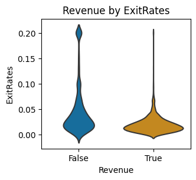

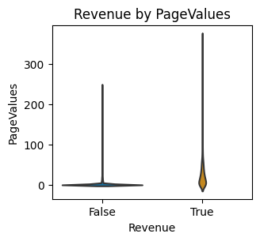

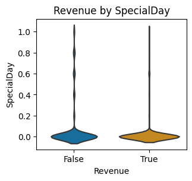

```python
# Check the distributions of the numeric variables using violin plots.
num_all_columns = ['Administrative', 'Administrative_Duration', 'Informational',
       'Informational_Duration', 'ProductRelated', 'ProductRelated_Duration',
       'BounceRates', 'ExitRates', 'PageValues', 'SpecialDay']

for i in range(len(num_all_columns)):
    plt.figure(figsize=(15, 20))
    plt.subplot(6, 4, i + 1)
    sns.violinplot(x=df['Revenue'], y=df[num_all_columns[i]], data=df, inner=None, palette='colorblind')
    plt.title('Revenue by {}'.format(num_all_columns[i]))
    plt.show()
```

Insights derived from the violin plots are the higher the number of pages visited the more customers will purchase something. Another insight is customers who purchased an item have shorter exit rates and bounce rates than those customers that did not purchase an item. One strategy to keep customers on the website longer is providing items they are interested in purchasing through a recommender system.

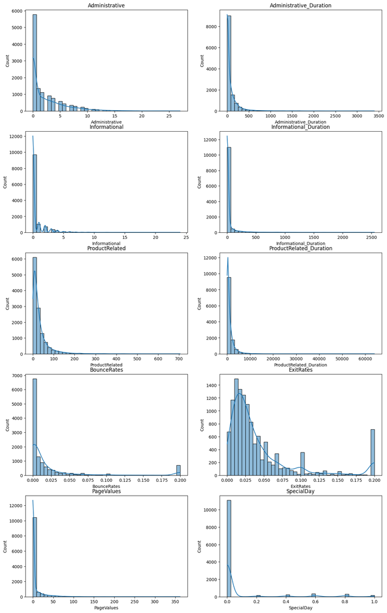

```python
# Check the distributions of the numeric variables.
num_all_columns = ['Administrative', 'Administrative_Duration', 'Informational',
       'Informational_Duration', 'ProductRelated', 'ProductRelated_Duration',
       'BounceRates', 'ExitRates', 'PageValues', 'SpecialDay']

plt.figure(figsize=(15, 30))

for i in range(len(num_all_columns)):
    plt.subplot(6, 2, i + 1)
    sns.histplot(num_df[num_all_columns[i]], kde=True, bins=40)
    plt.title(num_all_columns[i])
```

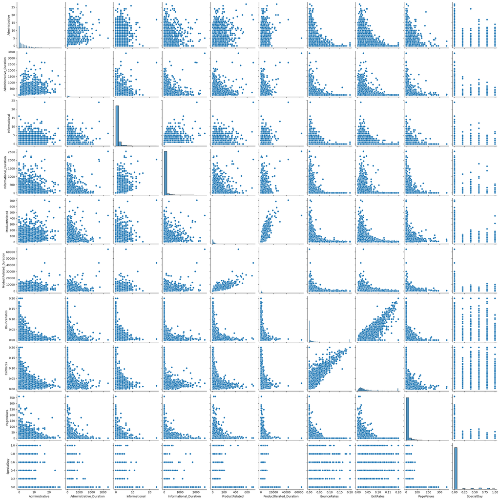

```python
# Plot pairplots to check see the relationship between the numeric variables.
sns.pairplot(num_df)
plt.show()
```

I suspect there is multicollinearity based on the scatterplots. I will verify this with a heatmap of the correlation matrix.

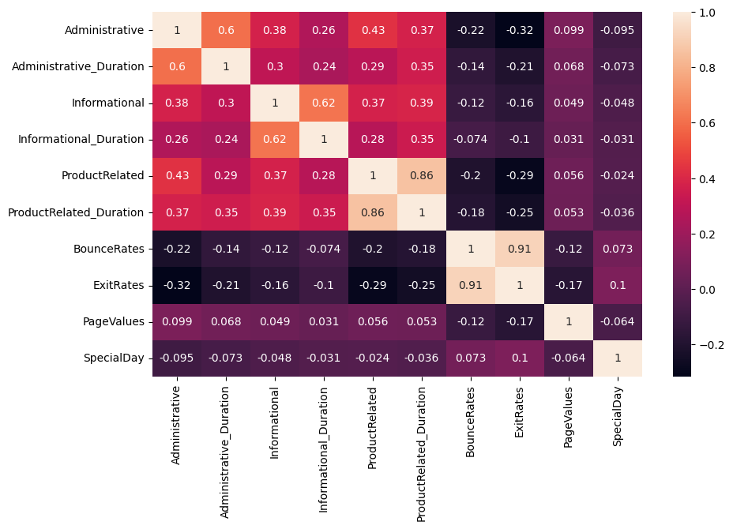

```python
# Check for multicollinearity with a heatmap.
corr_matrix = round(num_df.corr(), 3)

plt.figure(figsize=(10,6))
sns.heatmap(corr_matrix, annot=True)
plt.show()
```

```python
# Drop columns 'ProductRelated' and 'ExitRates' because of high correlation to another variable.
new_num_df = num_df.drop(['ProductRelated', 'ExitRates'], axis=1)
```

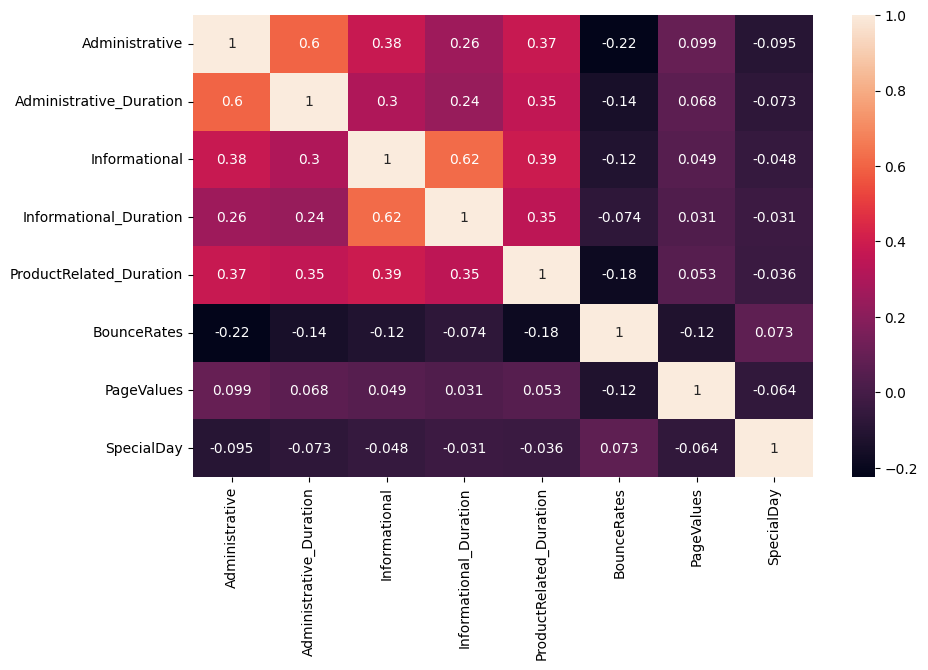

```python
# Check for multicollinearity with a heatmap after dropping ProductRelated and ExitRates.
new_corr_matrix = round(new_num_df.corr(), 3)

plt.figure(figsize=(10,6))
sns.heatmap(new_corr_matrix, annot=True)
plt.show()
```

```python
# Concatenate num_df and cat_df to form online_df.
df = pd.concat([new_num_df, cat_df], axis = 1)
```

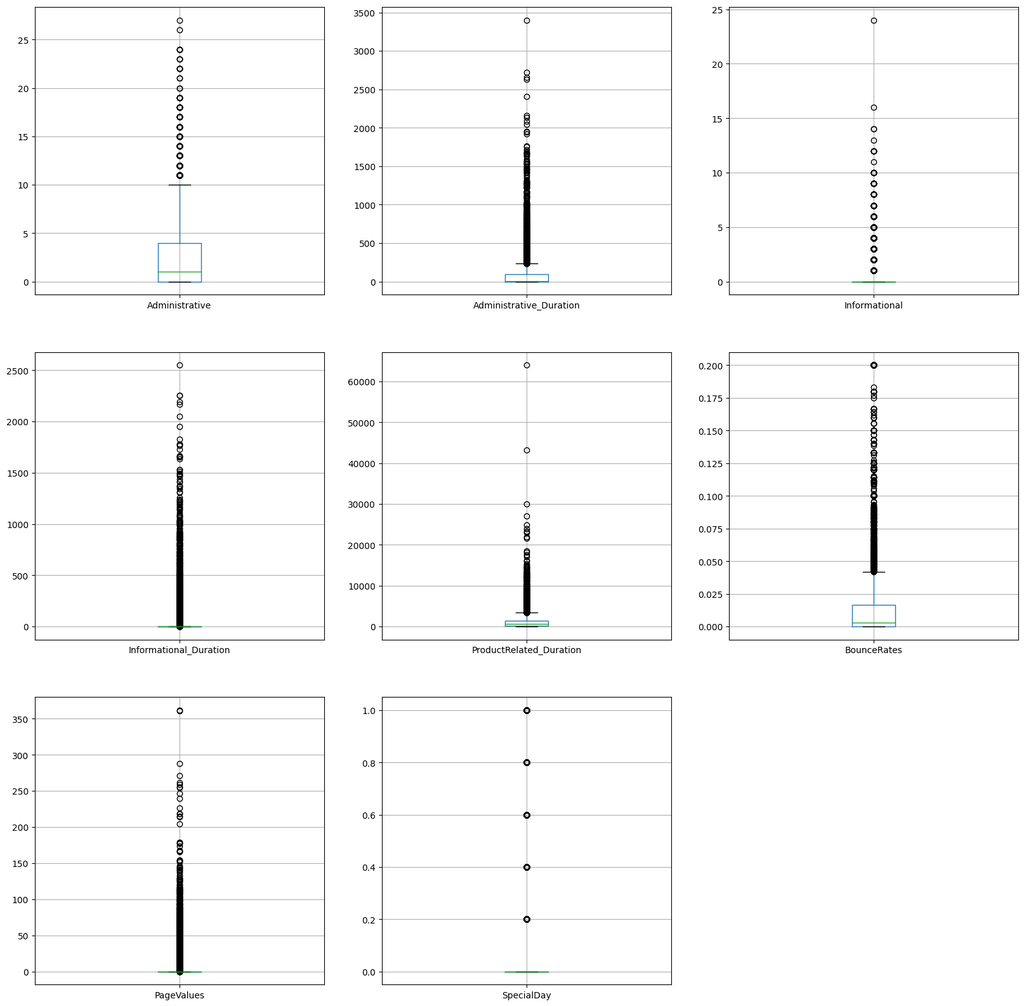

```python
# Detect outliers through plotting box plots
plt.figure(figsize=(20,20))
for i, col in enumerate(['Administrative', 'Administrative_Duration', 'Informational', 'Informational_Duration',
       'ProductRelated_Duration', 'BounceRates', 'PageValues', 'SpecialDay'], start=1):
    plt.subplot(3, 3, i)
    num_df.boxplot(col,whis=1.5)

plt.show()
```

```python
# Calculate number of outliers and its percentage with Tukey's method.
for i, col in enumerate(['Administrative', 'Administrative_Duration', 'Informational', 'Informational_Duration',
       'ProductRelated_Duration', 'BounceRates', 'PageValues', 'SpecialDay'], start=1):
    q75, q25 = np.percentile(new_num_df[col], [75, 25])
    iqr = q75 - q25

    min_val = q25 - (iqr*1.5)
    max_val = q75 + (iqr*1.5)
    print("Number of outliers and percentage of it in {} : {} and {}".format(col,
                                                                            len((np.where((new_num_df[col] > max_val) |
                                                                                           (new_num_df[col] < min_val))[0])),
                                                                             len((np.where((new_num_df[col] > max_val) |
                                                                                           (new_num_df[col] < min_val))[0]))*100/12330))
```

```
Number of outliers and percentage of it in Administrative : 404 and 3.276561232765612
Number of outliers and percentage of it in Administrative_Duration : 1172 and 9.505271695052716
Number of outliers and percentage of it in Informational : 2631 and 21.338199513381994
Number of outliers and percentage of it in Informational_Duration : 2405 and 19.505271695052716
Number of outliers and percentage of it in ProductRelated_Duration : 961 and 7.7939983779399835
Number of outliers and percentage of it in BounceRates : 1551 and 12.579075425790755
Number of outliers and percentage of it in PageValues : 2730 and 22.14111922141119
Number of outliers and percentage of it in SpecialDay : 1251 and 10.145985401459853
```

I can see all eight of the numeric variables have outliers. I will correct for these outliers with StandardScaler in the preprocessing of data step.

# Data Pre-Processing

```python
# Define X and y.
y = df['Revenue']
X = df.drop(['Revenue'], axis=1)
```

```python
# Splitting the data into train (80%) and test (20%) data.
from sklearn.model_selection import train_test_split
X_train, X_test, y_train, y_test = train_test_split(X, y, test_size=0.20, random_state=2, stratify=y)
```

```python
# Loading libraries for preprocessing data and creating pipelines.
from sklearn.compose import ColumnTransformer
from sklearn.preprocessing import StandardScaler, OneHotEncoder
from sklearn.pipeline import Pipeline
```

```python
# Create pipelines to transform numeric and categorical variables.
numeric_transformer = Pipeline(steps=[
    ('scaler', StandardScaler())])

categorical_transformer = Pipeline(steps=[
    ('onehot', OneHotEncoder(handle_unknown='ignore'))])
```

```python
# Split data into numeric and categorical variables.
numeric_features = X_train.select_dtypes(include=['int64', 'float64']).columns
categorical_features = X_train.select_dtypes(include=['object']).columns
```

```python
# Apply transformations to the correct columns.
preprocessor = ColumnTransformer(
    transformers=[
        ('num', numeric_transformer, numeric_features),
        ('cat', categorical_transformer, categorical_features)])
```

# Model Selection

```python
# Load libraries
from pandas import set_option
from sklearn.model_selection import KFold
from sklearn.metrics import classification_report
from sklearn.model_selection import StratifiedKFold
from sklearn.model_selection import cross_val_score
from sklearn.metrics import classification_report
from sklearn.model_selection import GridSearchCV
from sklearn.metrics import confusion_matrix
from sklearn.metrics import accuracy_score
from sklearn.linear_model import LogisticRegression
from sklearn.tree import DecisionTreeClassifier
from sklearn.naive_bayes import GaussianNB
from sklearn.svm import SVC, NuSVC
from sklearn.ensemble import AdaBoostClassifier
from sklearn.ensemble import GradientBoostingClassifier
from sklearn.ensemble import RandomForestClassifier
from sklearn.ensemble import ExtraTreesClassifier
from sklearn.neural_network import MLPClassifier
```

```python
# Create a list classifiers to use pipeline in model selection.
classifiers = [
    LogisticRegression(),
    SVC(kernel='rbf', C=0.025, probability=True),
    DecisionTreeClassifier(),
    RandomForestClassifier(),
    GradientBoostingClassifier(),
    MLPClassifier()
    ]
```

```python
# Create a pipeline for the various classifiers to use for model selection.
# https://www.codementor.io/@bruce3557/beautiful-machine-learning-pipeline-with-scikit-learn-uiqapbxuj
for classifier in classifiers:
    pipe = Pipeline(steps=[('preprocessor', preprocessor),
                           ('classifier', classifier)
                            ])
    pipe.fit(X_train, y_train)
    print(classifier)
    print('Model score: %.3f' % pipe.score(X_test, y_test))

# Display classification report for all the models for model selection.
    y_pred = pipe.predict(X_test)
    results = confusion_matrix(y_test, y_pred)
    print('Confusion Matrix: ')
    print(results)
    print('Classification Report: ')
    print(classification_report(y_test, y_pred))
```

```
LogisticRegression()
Model score: 0.880
Confusion Matrix:
[[2033   51]
 [ 246  136]]
Classification Report:
              precision    recall  f1-score   support

       False       0.89      0.98      0.93      2084
        True       0.73      0.36      0.48       382

    accuracy                           0.88      2466
   macro avg       0.81      0.67      0.70      2466
weighted avg       0.87      0.88      0.86      2466

SVC(C=0.025, probability=True)
Model score: 0.870
Confusion Matrix:
[[2051   33]
 [ 288   94]]
Classification Report:
              precision    recall  f1-score   support

       False       0.88      0.98      0.93      2084
        True       0.74      0.25      0.37       382

    accuracy                           0.87      2466
   macro avg       0.81      0.62      0.65      2466
weighted avg       0.86      0.87      0.84      2466

DecisionTreeClassifier()
Model score: 0.859
Confusion Matrix:
[[1912  172]
 [ 176  206]]
Classification Report:
              precision    recall  f1-score   support

       False       0.92      0.92      0.92      2084
        True       0.54      0.54      0.54       382
```

[output cut: 34 more lines]

```

MLPClassifier()
Model score: 0.873
Confusion Matrix:
[[1941  143]
 [ 170  212]]
Classification Report:
              precision    recall  f1-score   support

       False       0.92      0.93      0.93      2084
        True       0.60      0.55      0.58       382

    accuracy                           0.87      2466
   macro avg       0.76      0.74      0.75      2466
weighted avg       0.87      0.87      0.87      2466
```